# Notebook

[figure not shown]

Artificial Intelligence and Machine Learning

Advanced Machine Learning - Project Debrief

[figure not shown]

Visa Approval Facilitation

## Problem Statement

### Context:

Business communities in the United States are facing high demand for human resources, but one of the constant challenges is identifying and attracting the right talent, which is perhaps the most important element in remaining competitive. Companies in the United States look for hard-working, talented, and qualified individuals both locally as well as abroad.

The Immigration and Nationality Act (INA) of the US permits foreign workers to come to the United States to work on either a temporary or permanent basis. The act also protects US workers against adverse impacts on their wages or working conditions by ensuring US employers' compliance with statutory requirements when they hire foreign workers to fill workforce shortages. The immigration programs are administered by the Office of Foreign Labor Certification (OFLC).

OFLC processes job certification applications for employers seeking to bring foreign workers into the United States and grants certifications in those cases where employers can demonstrate that there are not sufficient US workers available to perform the work at wages that meet or exceed the wage paid for the occupation in the area of intended employment.

### Objective:

In FY 2016, the OFLC processed 775,979 employer applications for 1,699,957 positions for temporary and permanent labor certifications. This was a nine percent increase in the overall number of processed applications from the previous year. The process of reviewing every case is becoming a tedious task as the number of applicants is increasing every year.

The increasing number of applicants every year calls for a Machine Learning based solution that can help in shortlisting the candidates having higher chances of VISA approval. OFLC has hired the firm EasyVisa for data-driven solutions. You as a data scientist at EasyVisa have to analyze the data provided and, with the help of a classification model:

- Facilitate the process of visa approvals.
- Recommend a suitable profile for the applicants for whom the visa should be certified or denied based on the drivers that significantly influence the case status.

### Data Description

The data contains the different attributes of employee and the employer. The detailed data dictionary is given below.

- case_id: ID of each visa application
- continent: Information of continent the employee
- education_of_employee: Information of education of the employee
- has_job_experience: Does the employee has any job experience? Y= Yes; N = No
- requires_job_training: Does the employee require any job training? Y = Yes; N = No
- no_of_employees: Number of employees in the employer's company
- yr_of_estab: Year in which the employer's company was established
- region_of_employment: Information of foreign worker's intended region of employment in the US.
- prevailing_wage: Average wage paid to similarly employed workers in a specific occupation in the area of intended employment. The purpose of the prevailing wage is to ensure that the foreign worker is not underpaid compared to other workers offering the same or similar service in the same area of employment.
- unit_of_wage: Unit of prevailing wage. Values include Hourly, Weekly, Monthly, and Yearly.
- full_time_position: Is the position of work full-time? Y = Full Time Position; N = Part Time Position
- case_status: Flag indicating if the Visa was certified or denied

## Importing necessary libraries

```python
# Installing the libraries with the specified version.
!pip install pandas==2.2.2 numpy==1.23.5 scikit-learn==1.5.2 matplotlib==3.8.0 seaborn==0.13.1 xgboost==2.0.3 -q --user
```

**Note**: *After running the above cell, kindly restart the notebook kernel and run all cells sequentially from the below.*

```python
# Import Required Libraries
import pandas as pd
import numpy as np
import matplotlib.pyplot as plt
import seaborn as sns
from sklearn.model_selection import train_test_split
from sklearn.preprocessing import LabelEncoder, StandardScaler
from imblearn.over_sampling import SMOTE
from imblearn.under_sampling import RandomUnderSampler
from sklearn.tree import DecisionTreeClassifier
from sklearn.ensemble import BaggingClassifier, RandomForestClassifier, AdaBoostClassifier, GradientBoostingClassifier
from sklearn.metrics import accuracy_score, classification_report, confusion_matrix
```

```python
# Importing the warnings module to manage warning messages in Python.
import warnings

# Suppressing warnings of category FutureWarning to prevent messages about
# features or libraries that may change in the future.
warnings.filterwarnings("ignore", category=FutureWarning)

# Suppressing warnings of category UserWarning to avoid non-critical user-level warnings.
warnings.filterwarnings("ignore", category=UserWarning)
```

## Import Dataset

```python
# Mount on my drive
from google.colab import drive
drive.mount('/content/drive')
```

```python
# Load Dataset
EVisa = pd.read_csv('/content/drive/My Drive/Colab Notebooks/Machine Learning/PROJECT 3/EasyVisa.csv')
# A copy of the original dataset before performing any operations
data = EVisa.copy()
```

## Overview of the Dataset

#### View the first and last 5 rows of the dataset

```python
# Display basic information
data.info()
```

```
<class 'pandas.core.frame.DataFrame'>
RangeIndex: 25480 entries, 0 to 25479
Data columns (total 12 columns):
 #   Column                 Non-Null Count  Dtype
---  ------                 --------------  -----
 0   case_id                25480 non-null  object
 1   continent              25480 non-null  object
 2   education_of_employee  25480 non-null  object
 3   has_job_experience     25480 non-null  object
 4   requires_job_training  25480 non-null  object
 5   no_of_employees        25480 non-null  int64
 6   yr_of_estab            25480 non-null  int64
 7   region_of_employment   25480 non-null  object
 8   prevailing_wage        25480 non-null  float64
 9   unit_of_wage           25480 non-null  object
 10  full_time_position     25480 non-null  object
 11  case_status            25480 non-null  object
dtypes: float64(1), int64(2), object(9)
memory usage: 2.3+ MB
```

```python
# First 5 rows
display(data.head(5))
```

|  | case_id | continent | education_of_employee | has_job_experience | requires_job_training | no_of_employees | yr_of_estab | region_of_employment | prevailing_wage | unit_of_wage | full_time_position | case_status |
| --- | --- | --- | --- | --- | --- | --- | --- | --- | --- | --- | --- | --- |
| 0 | EZYV01 | Asia | High School | N | N | 14513 | 2007 | West | 592.2029 | Hour | Y | Denied |
| 1 | EZYV02 | Asia | Master's | Y | N | 2412 | 2002 | Northeast | 83425.6500 | Year | Y | Certified |
| 2 | EZYV03 | Asia | Bachelor's | N | Y | 44444 | 2008 | West | 122996.8600 | Year | Y | Denied |
| 3 | EZYV04 | Asia | Bachelor's | N | N | 98 | 1897 | West | 83434.0300 | Year | Y | Denied |
| 4 | EZYV05 | Africa | Master's | Y | N | 1082 | 2005 | South | 149907.3900 | Year | Y | Certified |

```python
# Last 5 rows
display(data.tail())
```

|  | case_id | continent | education_of_employee | has_job_experience | requires_job_training | no_of_employees | yr_of_estab | region_of_employment | prevailing_wage | unit_of_wage | full_time_position | case_status |
| --- | --- | --- | --- | --- | --- | --- | --- | --- | --- | --- | --- | --- |
| 25475 | EZYV25476 | Asia | Bachelor's | Y | Y | 2601 | 2008 | South | 77092.57 | Year | Y | Certified |
| 25476 | EZYV25477 | Asia | High School | Y | N | 3274 | 2006 | Northeast | 279174.79 | Year | Y | Certified |
| 25477 | EZYV25478 | Asia | Master's | Y | N | 1121 | 1910 | South | 146298.85 | Year | N | Certified |
| 25478 | EZYV25479 | Asia | Master's | Y | Y | 1918 | 1887 | West | 86154.77 | Year | Y | Certified |
| 25479 | EZYV25480 | Asia | Bachelor's | Y | N | 3195 | 1960 | Midwest | 70876.91 | Year | Y | Certified |

#### Understand the shape of the dataset

```python
print("Dataset Shape:", data.shape)
```

```
Dataset Shape: (25480, 12)
```

#### Check the data types of the columns for the dataset

```python
print("\nData Types:\n", data.dtypes)
```

```
Data Types:
 case_id                   object
continent                 object
education_of_employee     object
has_job_experience        object
requires_job_training     object
no_of_employees            int64
yr_of_estab                int64
region_of_employment      object
prevailing_wage          float64
unit_of_wage              object
full_time_position        object
case_status               object
dtype: object
```

## Exploratory Data Analysis (EDA)

#### Let's check the statistical summary of the data

```python
print("\nStatistical Summary:\n")
display(data.describe(include='all'))
```

```
Statistical Summary:
```

|  | case_id | continent | education_of_employee | has_job_experience | requires_job_training | no_of_employees | yr_of_estab | region_of_employment | prevailing_wage | unit_of_wage | full_time_position | case_status |
| --- | --- | --- | --- | --- | --- | --- | --- | --- | --- | --- | --- | --- |
| count | 25480 | 25480 | 25480 | 25480 | 25480 | 25480.000000 | 25480.000000 | 25480 | 25480.000000 | 25480 | 25480 | 25480 |
| unique | 25480 | 6 | 4 | 2 | 2 | NaN | NaN | 5 | NaN | 4 | 2 | 2 |
| top | EZYV25480 | Asia | Bachelor's | Y | N | NaN | NaN | Northeast | NaN | Year | Y | Certified |
| freq | 1 | 16861 | 10234 | 14802 | 22525 | NaN | NaN | 7195 | NaN | 22962 | 22773 | 17018 |
| mean | NaN | NaN | NaN | NaN | NaN | 5667.043210 | 1979.409929 | NaN | 74455.814592 | NaN | NaN | NaN |
| std | NaN | NaN | NaN | NaN | NaN | 22877.928848 | 42.366929 | NaN | 52815.942327 | NaN | NaN | NaN |
| min | NaN | NaN | NaN | NaN | NaN | -26.000000 | 1800.000000 | NaN | 2.136700 | NaN | NaN | NaN |
| 25% | NaN | NaN | NaN | NaN | NaN | 1022.000000 | 1976.000000 | NaN | 34015.480000 | NaN | NaN | NaN |
| 50% | NaN | NaN | NaN | NaN | NaN | 2109.000000 | 1997.000000 | NaN | 70308.210000 | NaN | NaN | NaN |
| 75% | NaN | NaN | NaN | NaN | NaN | 3504.000000 | 2005.000000 | NaN | 107735.512500 | NaN | NaN | NaN |
| max | NaN | NaN | NaN | NaN | NaN | 602069.000000 | 2016.000000 | NaN | 319210.270000 | NaN | NaN | NaN |

#### Fixing the negative values in number of employees columns

```python
# Check for negative values in the numeric columns
numeric_columns = ['no_of_employees', 'yr_of_estab', 'prevailing_wage']
negative_values_count = (data[numeric_columns] < 0).sum()

# Display the count of negative values for each numeric column
print(negative_values_count)
```

```
no_of_employees    33
yr_of_estab         0
prevailing_wage     0
dtype: int64
```

```python
# The negative values in 'no_of_employees'
negative_values_in_no_of_employees = data.loc[data['no_of_employees'] < 0, 'no_of_employees']
print(negative_values_in_no_of_employees)
```

```
245     -25
378     -11
832     -17
2918    -26
6439    -14
6634    -26
7224    -25
7281    -14
7318    -26
7761    -11
9872    -26
11493   -14
13471   -17
14022   -11
14146   -26
```

[output cut: 19 more lines]

```python
# Drop rows where 'no_of_employees' is negative
data = data[data['no_of_employees'] > 0]

# Check the shape of the dataset after dropping
print(data.shape)
```

```
(25447, 12)
```

```python
print("\nStatistical Summary:\n")
display(data['no_of_employees'].describe())
```

```
Statistical Summary:
```

|  | no_of_employees |
| --- | --- |
| count | 25447.000000 |
| mean | 5674.415334 |
| std | 22891.842245 |
| min | 12.000000 |
| 25% | 1025.000000 |
| 50% | 2112.000000 |
| 75% | 3506.500000 |
| max | 602069.000000 |

**dtype:** float64

```python
# Filter rows where 'no_of_employees' is less than 100
filtered_data = data[data['no_of_employees'] < 100]

# Select relevant columns to display
filtered_data = filtered_data[['no_of_employees', 'case_status', 'yr_of_estab']]

# Sort the data in ascending order based on 'no_of_employees'
sorted_filtered_data = filtered_data.sort_values(by='no_of_employees', ascending=True)

# Display the sorted data
print(sorted_filtered_data)
```

```
       no_of_employees case_status  yr_of_estab
21804               12      Denied         2004
16626               12      Denied         2009
13297               12   Certified         2008
1826                13   Certified         1989
5700                15   Certified         2003
...                ...         ...          ...
21438               99   Certified         1817
6693                99   Certified         1895
8232                99   Certified         1996
3750                99      Denied         1881
5043                99   Certified         1977

[526 rows x 3 columns]
```

#### Let's check the count of each unique category in each of the categorical variables

```python
# List of categorical columns
categorical_columns = ['case_id', 'continent', 'education_of_employee', 'has_job_experience',
                       'requires_job_training', 'region_of_employment', 'unit_of_wage',
                       'full_time_position', 'case_status']

# Check the count of each unique category in the categorical columns
for column in categorical_columns:
    print(f"Value counts for {column}:")
    print(data[column].value_counts())
    print("\n")
```

```
Value counts for case_id:
case_id
EZYV25480    1
EZYV01       1
EZYV02       1
EZYV03       1
EZYV04       1
            ..
EZYV12       1
EZYV11       1
EZYV10       1
EZYV09       1
EZYV08       1
Name: count, Length: 25447, dtype: int64


Value counts for continent:
continent
Asia             16840
Europe            3727
North America     3287
South America      851
Africa             550
Oceania            192
Name: count, dtype: int64


Value counts for education_of_employee:
education_of_employee
Bachelor's     10220
Master's        9622
High School     3416
Doctorate       2189
Name: count, dtype: int64


Value counts for has_job_experience:
has_job_experience
Y    14786
N    10661
```

[output cut: 26 more lines]

```
Name: count, dtype: int64


Value counts for full_time_position:
full_time_position
Y    22741
N     2706
Name: count, dtype: int64


Value counts for case_status:
case_status
Certified    17001
Denied        8446
Name: count, dtype: int64
```

### Univariate Analysis

```python
def histogram_boxplot(data, feature, figsize=(15, 10), kde=False, bins=None):
    """
    Boxplot and histogram combined

    data: dataframe
    feature: dataframe column
    figsize: size of figure (default (15,10))
    kde: whether to show the density curve (default False)
    bins: number of bins for histogram (default None)
    """
    f2, (ax_box2, ax_hist2) = plt.subplots(
        nrows=2,  # Number of rows of the subplot grid= 2
        sharex=True,  # x-axis will be shared among all subplots
        gridspec_kw={"height_ratios": (0.25, 0.75)},
        figsize=figsize,
    )  # creating the 2 subplots
    sns.boxplot(
        data=data, x=feature, ax=ax_box2, showmeans=True, color="violet"
    )  # boxplot will be created and a triangle will indicate the mean value of the column
    sns.histplot(
        data=data, x=feature, kde=kde, ax=ax_hist2, bins=bins
    ) if bins else sns.histplot(
        data=data, x=feature, kde=kde, ax=ax_hist2
    )  # For histogram
    ax_hist2.axvline(
        data[feature].mean(), color="green", linestyle="--"
    )  # Add mean to the histogram
    ax_hist2.axvline(
        data[feature].median(), color="black", linestyle="-"
    )  # Add median to the histogram


    plt.show()  # Display the plot
```

```
Univariate Analysis for: no_of_employees
```

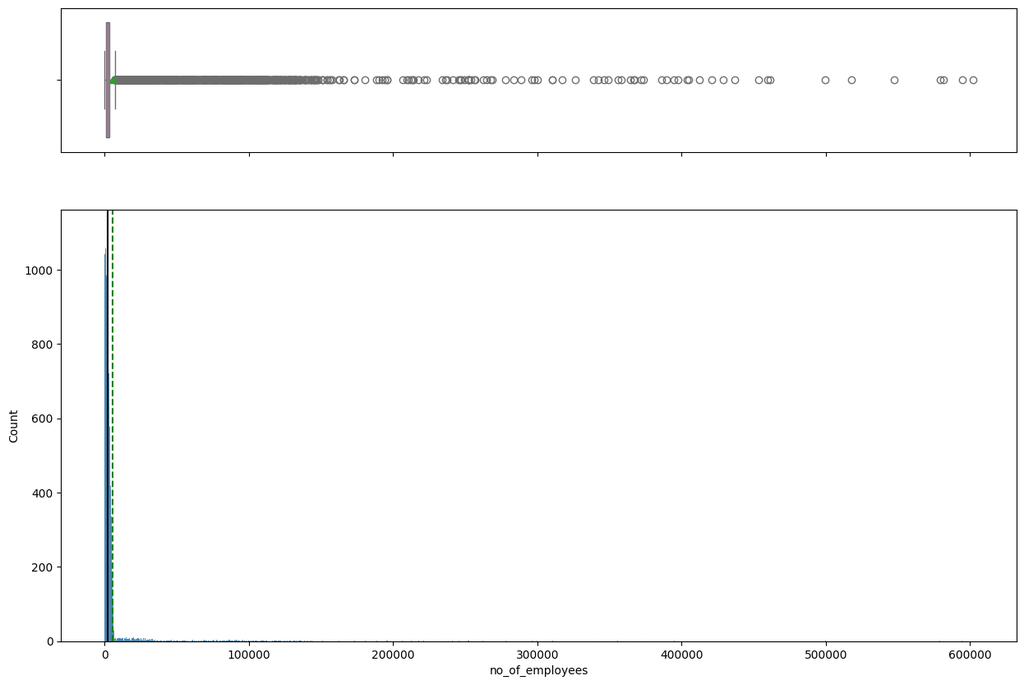

```
Univariate Analysis for: yr_of_estab
```

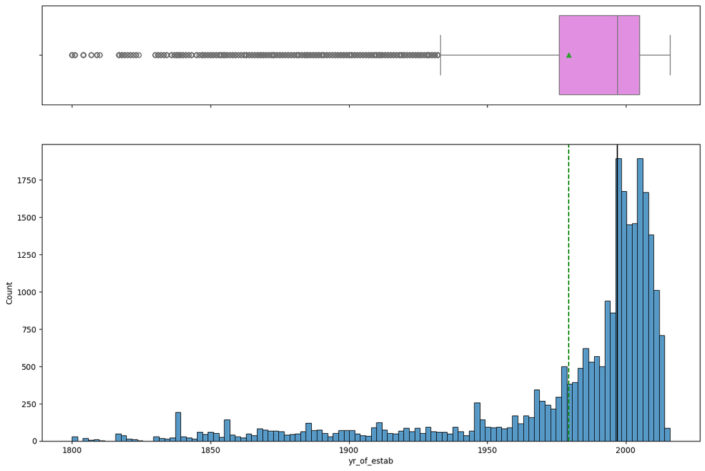

```
Univariate Analysis for: prevailing_wage
```

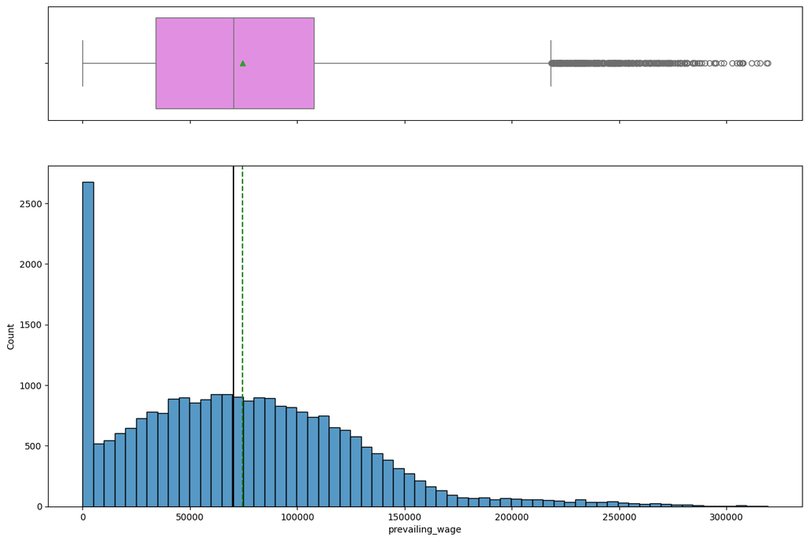

```python
# Loop through all numerical columns and plot
numerical_cols = data.select_dtypes(include=['int64', 'float64']).columns

for col in numerical_cols:
    print(f"Univariate Analysis for: {col}")
    histogram_boxplot(data, col)
```

#### Observations - Univariate Analysis:

**1. Number of Employees:**

**2. Year of Establishment:**

- The majority of establishments were founded after 1980, with a peak in the 1990s and early 2000s.
- A few very old establishments exist, leading to some outliers in the boxplot.
- The distribution shows that the number of new establishments increased significantly over time.

**3. Prevailing Wage:**

- The wage distribution is right-skewed, meaning most employees earn lower wages, while a few earn significantly higher wages.
- The boxplot shows outliers in the upper range.
- The histogram indicates a peak in the lower wage range, suggesting a large portion of employees earn wages within a narrow band.

```python
# function to create labeled barplots


def labeled_barplot(data, feature, perc=False, n=None):
    """
    Barplot with percentage at the top

    data: dataframe
    feature: dataframe column
    perc: whether to display percentages instead of count (default is False)
    n: displays the top n category levels (default is None, i.e., display all levels)
    """

    total = len(data[feature])  # length of the column
    count = data[feature].nunique()
    if n is None:
        plt.figure(figsize=(count + 1, 5))
    else:
        plt.figure(figsize=(n + 1, 5))

    plt.xticks(rotation=90, fontsize=15)
    ax = sns.countplot(
        data=data,
        x=feature,
        palette="Paired",
        order=data[feature].value_counts().index[:n].sort_values(),
    )

    for p in ax.patches:
        if perc == True:
            label = "{:.1f}%".format(
                100 * p.get_height() / total
            )  # percentage of each class of the category
        else:
            label = p.get_height()  # count of each level of the category

        x = p.get_x() + p.get_width() / 2  # width of the plot
        y = p.get_height()  # height of the plot

        ax.annotate(
            label,
            (x, y),
            ha="center",
            va="center",
            size=12,
            xytext=(0, 5),
            textcoords="offset points",
        )  # annotate the percentage

    plt.show()  # show the plot
```

#### Observations on education of employee

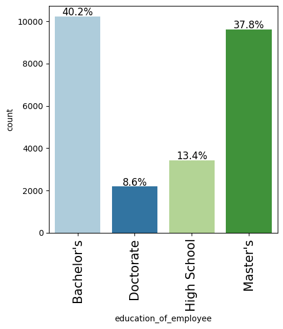

```python
labeled_barplot(data, "education_of_employee", perc=True)
```

**Education Level of Employees:**

- The majority of employees hold a Bachelor's (40.2%) or Master's (37.8%) degree.
- High school graduates make up 13.4%, and Doctorate holders are only 8.6%.

#### Observations on region of employment

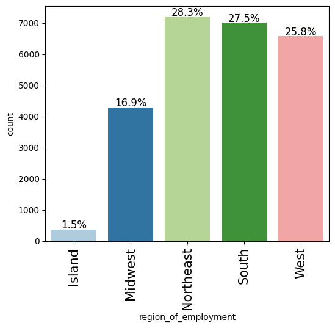

```python
labeled_barplot(data, "region_of_employment", perc=True)
```

**Employment Region:**

#### Observations on job experience

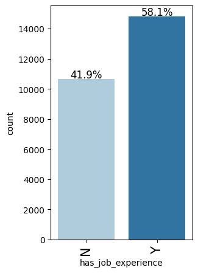

```python
labeled_barplot(data, "has_job_experience", perc=True)
```

**Job Experience Requirement:**

#### Observations on case status

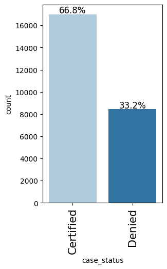

```python
labeled_barplot(data, "case_status", perc=True)
```

**Case Status (Approval vs. Denial):**

- 66.8% of applications are certified (approved), while 33.2% are denied.
- Indicates that nearly one-third of applications face rejection.

```
Plotting for continent...
```

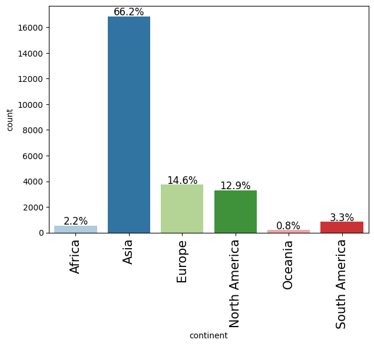

```
Plotting for has_job_experience...
```

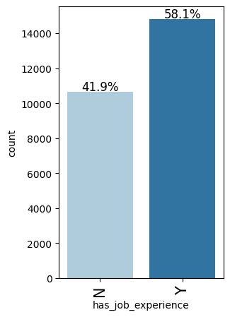

```
Plotting for requires_job_training...
```

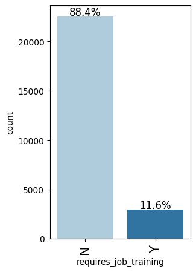

```
Plotting for unit_of_wage...
```

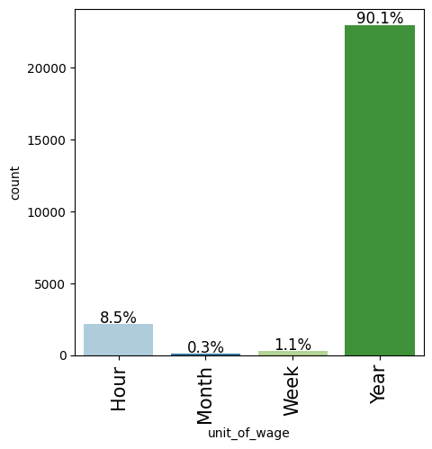

```
Plotting for full_time_position...
```

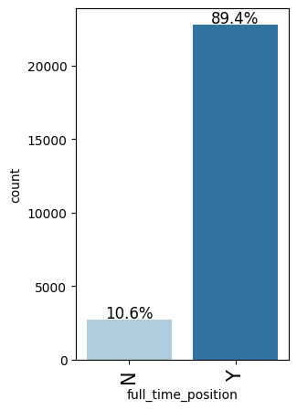

```python
categorical_columns = [
    "continent",
    "has_job_experience",
    "requires_job_training",
    "unit_of_wage",
    "full_time_position",

]
# Call labeled_barplot() only on selected categorical columns
for col in categorical_columns:
    print(f"Plotting for {col}...\n")
    labeled_barplot(data, col, perc=True)
```

#### Observations on rest of CAT variables

**Continent-wise Distribution of Employees:**

• Asia has the highest percentage (66.2%) of employees, followed by Europe (14.6%) and North America (12.9%).

• Africa, Oceania, and South America contribute very little to the workforce.

**Job Experience Requirement:**

• Indicates that prior experience is a key requirement in most roles.

**Job Training Requirement:** • Only 11.6% of jobs require training, while 88.4% do not.

• Suggests that employers expect candidates to have relevant skills before hiring.

**Unit of Wage Payment:** • 90.1% of wages are paid on a yearly basis.

• Hourly, weekly, and monthly wage payments make up a very small fraction.

**Full-time vs. Part-time Positions:**

• 89.4% of jobs are full-time, while 10.6% are part-time.

• Suggests that most positions in this dataset offer stable employment.

### Bivariate Analysis

**Creating functions that will help us with further analysis.**

```python
### function to plot distributions wrt target


def distribution_plot_wrt_target(data, predictor, target):

    fig, axs = plt.subplots(2, 2, figsize=(12, 10))

    target_uniq = data[target].unique()

    axs[0, 0].set_title("Distribution of target for target=" + str(target_uniq[0]))
    sns.histplot(
        data=data[data[target] == target_uniq[0]],
        x=predictor,
        kde=True,
        ax=axs[0, 0],
        color="teal",
        stat="density",
    )

    axs[0, 1].set_title("Distribution of target for target=" + str(target_uniq[1]))
    sns.histplot(
        data=data[data[target] == target_uniq[1]],
        x=predictor,
        kde=True,
        ax=axs[0, 1],
        color="orange",
        stat="density",
    )

    axs[1, 0].set_title("Boxplot w.r.t target")
    sns.boxplot(data=data, x=target, y=predictor, ax=axs[1, 0], palette="gist_rainbow")

    axs[1, 1].set_title("Boxplot (without outliers) w.r.t target")
    sns.boxplot(
        data=data,
        x=target,
        y=predictor,
        ax=axs[1, 1],
        showfliers=False,
        palette="gist_rainbow",
    )

    plt.tight_layout()
    plt.show()
```

```python
def stacked_barplot(data, predictor, target):
    """
    Print the category counts and plot a stacked bar chart

    data: dataframe
    predictor: independent variable
    target: target variable
    """
    count = data[predictor].nunique()
    sorter = data[target].value_counts().index[-1]
    tab1 = pd.crosstab(data[predictor], data[target], margins=True).sort_values(
        by=sorter, ascending=False
    )
    print(tab1)
    print("-" * 120)
    tab = pd.crosstab(data[predictor], data[target], normalize="index").sort_values(
        by=sorter, ascending=False
    )
    tab.plot(kind="bar", stacked=True, figsize=(count + 5, 5))
    plt.legend(
        loc="lower left", frameon=False,
    )
    plt.legend(loc="upper left", bbox_to_anchor=(1, 1))
    plt.show()
```

#### Those with higher education may want to travel abroad for a well-paid job. Let's find out if education has any impact on visa certification

```
### Impact of Education on Visa Certification ###
case_status            Certified  Denied    All
education_of_employee
All                        17001    8446  25447
Bachelor's                  6362    3858  10220
High School                 1164    2252   3416
Master's                    7565    2057   9622
Doctorate                   1910     279   2189
------------------------------------------------------------------------------------------------------------------------
```

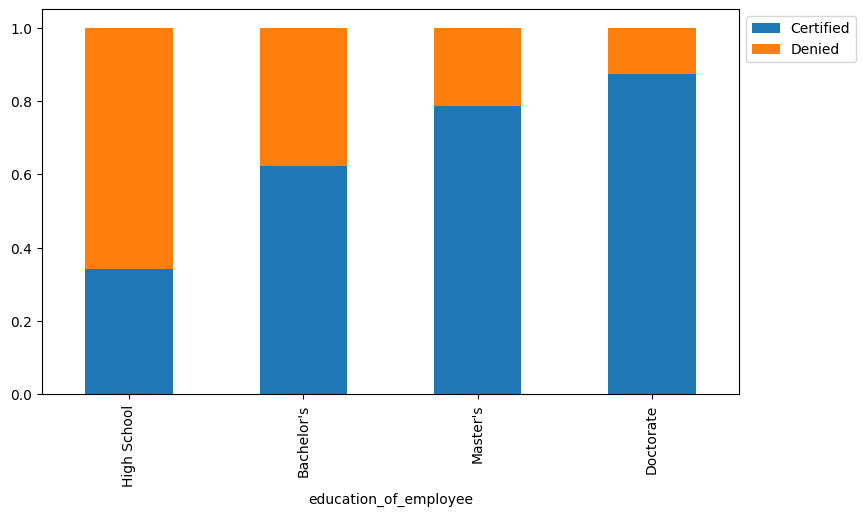

```python
# Impact of Education on Visa Certification
print("\n### Impact of Education on Visa Certification ###")
stacked_barplot(data, "education_of_employee","case_status")
```

• Yes, education has a significant impact on visa certification.

• As education level increases from High School to Doctorate, the certification rate steadily increases.

• Doctorate degree holders have the highest certification rate (approximately 85%).

• Master's degree holders have a good certification rate (about 80%).

• High school graduates have the lowest certification rate (about 35%).